# Case Study:Financial Inclusion in Rwanda

Morgan Mureithi

2025-05-30

#Loading Essential Libraries

```r
library(readr)
library(lifecycle)
library(dplyr)
library(stringr)
```

#Loading the data

```r
Mobile_Survey<- read.csv(file.choose())
View(Mobile_Survey)
```

#Re-arranging the data

```r
New_Mobile_Survey<-Mobile_Survey %>%
  group_by(hhid) %>%
  summarise(across(everything(),~paste0(unique(.),collapse = ",")))
View(New_Mobile_Survey)
```

#Adding new columns to the df

```r
New_Mobile_Survey<-New_Mobile_Survey %>%
  mutate(FE=account_type=="None",
          DFI=str_detect(account_type,"Mobile Money"))
View(New_Mobile_Survey)
View(New_Mobile_Survey %>%
       select(account_type,DFI))
```

#Establishing rates (%) of Financial Exclusion(FE)

```r
table(New_Mobile_Survey$FE)
```

```
##
## FALSE  TRUE
##  1074   131
```

```r
round(prop.table(table(New_Mobile_Survey$FE))*100,2)
```

```
##
## FALSE  TRUE
## 89.13 10.87
```

#Establishing rates (%) of Digital Financial Inclusion(DFI)

```r
table(New_Mobile_Survey$DFI)
```

```
##
## FALSE  TRUE
##   380   825
```

```r
round(prop.table(table(New_Mobile_Survey$DFI))*100,2)
```

```
##
## FALSE  TRUE
## 31.54 68.46
```

#Composition of the Mobile Money market w.r.t Co.

```r
unique(New_Mobile_Survey$mm_account_telco_main)
```

```
## [1] "Company_A" ""          "Company_B" "Company_C"
```

```r
New_Mobile_Survey<-New_Mobile_Survey %>%
  mutate(
    if_else(mm_account_telco_main == "" & mm_account_telco != "",
            mm_account_telco,mm_account_telco_main))
View(New_Mobile_Survey)
View(New_Mobile_Survey %>%
  select(mm_account_telco,mm_account_telco_main,`if_else(...)`))
New_Mobile_Survey<-New_Mobile_Survey %>%
  rename(Dominant_Companies = `if_else(...)`)
View(New_Mobile_Survey)
Companies_Market_Composition<-New_Mobile_Survey %>%
  filter(Dominant_Companies != "")
View(Companies_Market_Composition)
```

#Visualization of the Mobile Money market

```r
table(Companies_Market_Composition$Dominant_Companies)
```

```
##
## Company_A Company_B Company_C
##       459       345        21
```

```r
round(prop.table(table(Companies_Market_Composition$Dominant_Companies))*100,2)
```

```
##
## Company_A Company_B Company_C
##     55.64     41.82      2.55
```

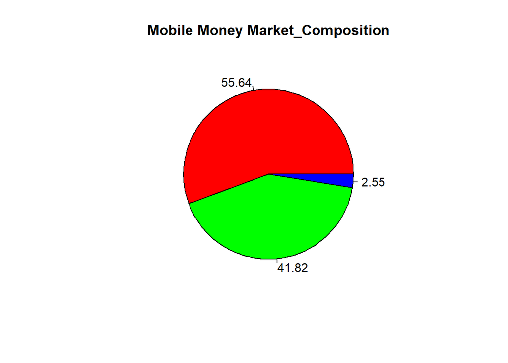

```r
label <- round(prop.table(table(Companies_Market_Composition$Dominant_Companies))*100,2)
Market_Size <- table(Companies_Market_Composition$Dominant_Companies)
pie(Market_Size, labels = label,
    main = "Mobile Money Market_Composition",
    col = rainbow(length(Market_Size)))
```

#Establishing transaction Failures in Urban & Rural areas ’’’ Test of Hypothesis(Two-tailed):Is there A difference in the share of customers who have experienced failures in Mobile Money transactions in Rural & Urban areas Ho:There is no significant difference in the share of customers who have experienced Mobile Money transaction failures in Rural & Urban areas Ha:There is a significant difference in the share of customers who have experienced Mobile Money transaction failures in Rural & Urban areas ’’’

```r
Falied_MM_Transactions <- New_Mobile_Survey %>%
  filter(mm_account == 'yes' & v240 == 'yes')#Caution:Must have Mobile Money A/C & Have experienced failure in Transacting
View(Falied_MM_Transactions)
table(Falied_MM_Transactions$urban,Falied_MM_Transactions$v240)
```

```
##
##         yes
##   Rural 131
##   Urban  83
```

```r
round(prop.table(table(Falied_MM_Transactions$urban,Falied_MM_Transactions$v240))*100,2)
```

```
##
##           yes
##   Rural 61.21
##   Urban 38.79
```

```r
#Test Statistic:Z-test Difference of Proportions
x1<-131
x2<-83
n1<-214
n2<-214
p1<-x1/n1
p2<-x2/n2
P<-(p1+p2)/(n1+n2)
SE<-sqrt(P*(1-P)*(1/n1 + 1/n2))
z<-(p1+p2)/SE
print(z)
```

```
## [1] 214.2504
```

```r
p_value<-2*(1-pnorm(abs(z)))
print(p_value)
```

```
## [1] 0
```

#Establishing Factors that lead to someone canceling their Mobile Money Account

```r
Will_cancel<-New_Mobile_Survey
View(Will_cancel)
```

#Handling Blanks by filling them with the mode in each column

```r
mode <- function(repeated) {
  unique_values <- unique(repeated[repeated != ""])
  unique_values[which.max(tabulate(match(repeated, unique_values)))]}
Will_cancel[] <- lapply(Will_cancel, function(col) {
  if (is.character(col)) {
    derived_mode <- mode(col)
    col[col == ""] <- derived_mode
  }
  return(col)
})
```

#Dropping some columns (based on Theory)

```r
View(Will_cancel)
Will_cancel <- Will_cancel[,-c(14,15,16,18,31)]
View(Will_cancel)
sum(is.na(Will_cancel))
```

```
## [1] 0
```

```r
str(Will_cancel)
```

```
## tibble [1,205 × 26] (S3: tbl_df/tbl/data.frame)
##  $ hhid                   : int [1:1205] 1001 1002 1003 1004 1005 1006 1007 1008 1009 1010 ...
##  $ weight                 : chr [1:1205] "145.94444" "122.90667" "760.46191" "433.96402" ...
##  $ account_num            : chr [1:1205] "1,2" "1,2,3" "1,2" "1" ...
##  $ account_type           : chr [1:1205] "SACCO Account,VSLA Account" "Mobile Money,Bank Account,VSLA Account" "Mobile Money,Bank Account" "Mobile Money" ...
##  $ district               : chr [1:1205] "District_A" "District_B" "District_A" "District_A" ...
##  $ urban                  : chr [1:1205] "Urban" "Rural" "Urban" "Rural" ...
##  $ gender                 : chr [1:1205] "male" "male" "male" "male" ...
##  $ age                    : chr [1:1205] "32" "32" "30" "68" ...
##  $ hh_members             : chr [1:1205] "1" "4" "8" "4" ...
##  $ highest_grade_completed: chr [1:1205] "primary 6" "primary 3" "secondary 6" "primary 6" ...
##  $ mm_account_cancelled   : chr [1:1205] "no" "yes" "no" "no" ...
##  $ prefer_cash            : chr [1:1205] "yes" "yes" "yes" "yes" ...
##  $ mm_trust               : chr [1:1205] "no" "no" "no" "no" ...
##  $ agent_trust            : chr [1:1205] "no" "no" "no" "no" ...
##  $ v237                   : chr [1:1205] "yes" "yes" "no" "no" ...
##  $ v238                   : chr [1:1205] "yes" "yes" "yes" "no" ...
##  $ v240                   : chr [1:1205] "no" "yes" "yes" "no" ...
##  $ v241                   : chr [1:1205] "yes" "no" "yes" "no" ...
##  $ v242                   : chr [1:1205] "no" "no" "no" "no" ...
##  $ v243                   : chr [1:1205] "yes" "no" "yes" "yes" ...
##  $ v244                   : chr [1:1205] "yes" "yes" "yes" "yes" ...
##  $ v245                   : chr [1:1205] "yes" "no" "yes" "no" ...
##  $ v246                   : chr [1:1205] "no" "no" "no" "no" ...
##  $ mm_account             : chr [1:1205] "yes" "no" "yes" "yes" ...
##  $ FE                     : logi [1:1205] FALSE FALSE FALSE FALSE TRUE FALSE ...
##  $ DFI                    : logi [1:1205] FALSE TRUE TRUE TRUE FALSE TRUE ...
```

```r
Select_Will_cancel <- Will_cancel %>%
  select(urban,gender,mm_trust,mm_account_cancelled,agent_trust,
         prefer_cash,v237,v238,v240,v241,v242,v243,v244,v245,v246)
View(Select_Will_cancel)
```

#Cramer Test for Association of categorical variables

```r
library(vcd)
```

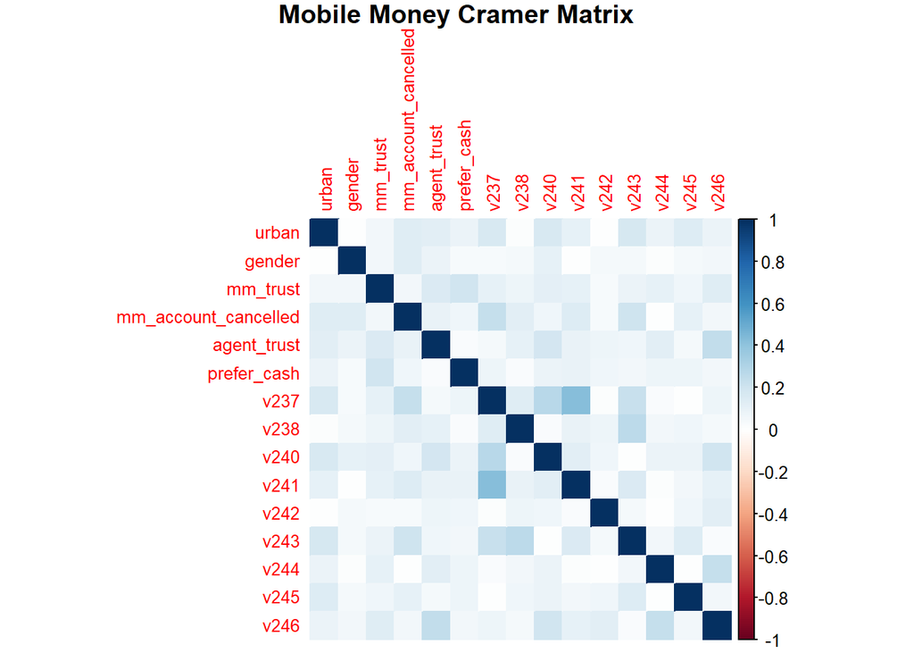

```r
Select_Will_cancel[] <- lapply(Select_Will_cancel,as.factor)
View(Select_Will_cancel)
cramers_v <- function(x, y) {
  table_association <- table(x, y)
  suppressWarnings(assocstats(table_association)$cramer)
}
var_names <- names(Select_Will_cancel)
n <- length(var_names)
cramer_matrix <- matrix(NA, n, n)
colnames(cramer_matrix) <- rownames(cramer_matrix) <- var_names
for (i in 1:n) {
  for (j in 1:n) {
    cramer_matrix[i, j] <- cramers_v(Select_Will_cancel[[i]],
                                     Select_Will_cancel[[j]])
  }
}
View(cramer_matrix)
library(corrplot)
corrplot(cramer_matrix, method = "color", tl.cex = 0.8, is.corr = TRUE,
         title = "Mobile Money Cramer Matrix", mar = c(0,0,1,0))
```